# Ford GoBike Dataset Exploratory Analysis

### Impact of Durations on different Variables

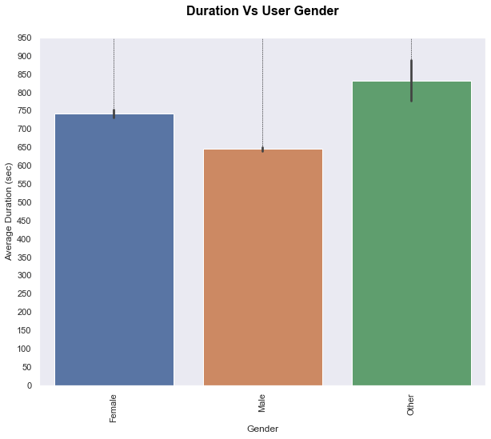

```python
sns.barplot(x='member_gender', y='duration_sec', data=df)
plt.xlabel('Gender');
plt.xticks(rotation=90);
plt.yticks(np.arange(0,1000,50));
plt.ylabel('Average Duration (sec)');
plt.title('Duration Vs User Gender', y=1.05, fontsize=16, fontweight='bold', color = 'black');
plt.grid(color = 'black', linestyle = '--', linewidth = 0.5);
```

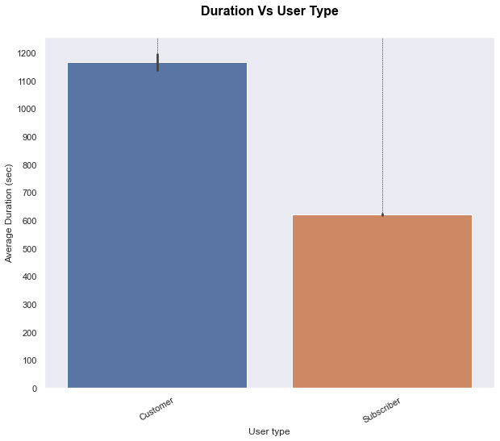

```python
sns.barplot(x='user_type', y='duration_sec', data=df)
plt.xlabel('User type');
plt.xticks(rotation=30);
plt.yticks(np.arange(0,1300,100));
plt.ylabel('Average Duration (sec)');
plt.title('Duration Vs User Type', y=1.05, fontsize=16, fontweight='bold', color = 'black');
plt.grid(color = 'black', linestyle = '--', linewidth = 0.5);
```

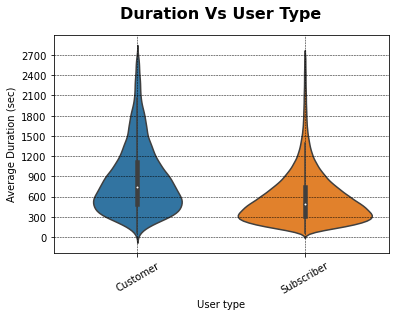

```python
sns.violinplot(x='user_type', y='duration_sec', data=df.query('duration_sec <= 2700'))
plt.xlabel('User type');
plt.xticks(rotation=30);
plt.yticks(np.arange(0,3000,300));
plt.ylabel('Average Duration (sec)');
plt.title('Duration Vs User Type', y=1.05, fontsize=16, fontweight='bold', color = 'black');
plt.grid(color = 'black', linestyle = '--', linewidth = 0.5);
```

It also seems that the subscribers have a lower standard deviation which means a more fixed schedule which is inline with the hypothesis that subscribers mainly use Ford Go Bike for commuting

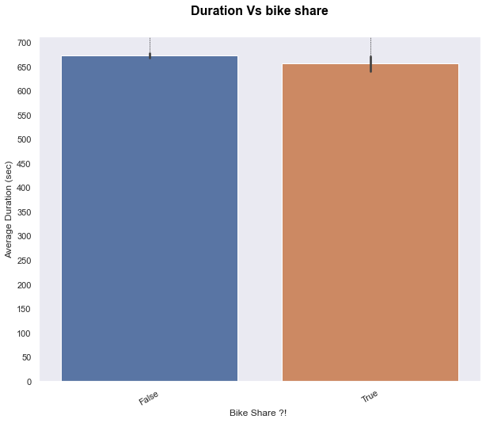

```python
sns.barplot(x='bike_share_for_all_trip', y='duration_sec', data=df)
plt.xlabel('Bike Share ?! ');
plt.xticks(rotation=30);
plt.yticks(np.arange(0,750,50));
plt.ylabel('Average Duration (sec)');
plt.title('Duration Vs bike share', y=1.05, fontsize=16, fontweight='bold', color = 'black');
plt.grid(color = 'black', linestyle = '--', linewidth = 0.5);
```

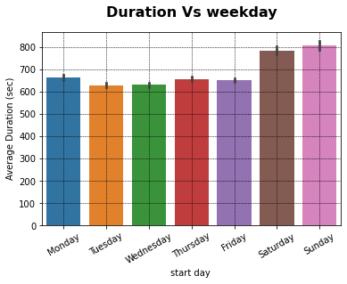

```python
order=['Monday', 'Tuesday', 'Wednesday', 'Thursday', 'Friday', 'Saturday', 'Sunday']
sns.barplot(x='start_day', y='duration_sec', data=df, order = order)
plt.xlabel('start day ');
plt.xticks(rotation=30);
plt.ylabel('Average Duration (sec)');
plt.title('Duration Vs weekday', y=1.05, fontsize=16, fontweight='bold', color = 'black');
plt.grid(color = 'black', linestyle = '--', linewidth = 0.5);
```

There seems to be a noticable increase in durations used on weekends than on weekdays which increases the chances of the recreational use trips on weekends

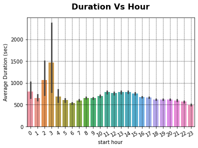

```python
sns.barplot(x='start_hour', y='duration_sec', data=df)
plt.xlabel('start hour');
plt.xticks(rotation=30);
plt.ylabel('Average Duration (sec)');
plt.title('Duration Vs Hour', y=1.05, fontsize=16, fontweight='bold', color = 'black');
plt.grid(color = 'black', linestyle = '--', linewidth = 0.5);
```

This is a little bit counter intuitive as the durations seem to drop in the commuting times in addition to having outliers & a wide margin of error in trips between midnight & dawn. which can somehow be explained by 2 far fetched hypothesis of: 1- People mainly use Ford Go bike to escape traffic in commuting times as durations decrease with the increase of the distance which somehow implies that traffic usually peaks during commuting hours. in addition to the recrational use mentioned before 2- people might forget to properly end their trips when riding at late nights which can explain the huge error & sudden spike in numbers but this needs a totally seperate investigations

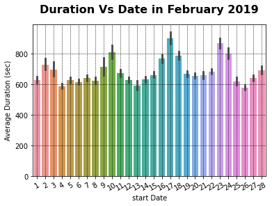

```python
sns.barplot(x='start_date', y='duration_sec', data=df)
plt.xlabel('start Date');
plt.xticks(rotation=30);
plt.ylabel('Average Duration (sec)');
plt.title('Duration Vs Date in February 2019', y=1.05, fontsize=16, fontweight='bold', color = 'black');
plt.grid(color = 'black', linestyle = '--', linewidth = 0.5);
```

The plot agrees with the hypothesis generated in the above plot regarding traffic as the average duration seems to increase in weekends across the month for recreational use & decrease during weekdays as people use them to avoid getting stuck in traffic

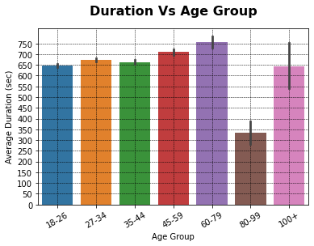

```python
sns.barplot(x='age_group', y='duration_sec', data=df)
plt.xlabel('Age Group');
plt.xticks(rotation=30);
plt.yticks(np.arange(0,800,50))
plt.ylabel('Average Duration (sec)');
plt.title('Duration Vs Age Group', y=1.05, fontsize=16, fontweight='bold', color = 'black');
plt.grid(color = 'black', linestyle = '--', linewidth = 0.5);
```

### Bivariant Count Plots

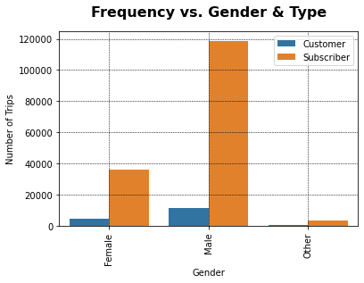

```python
sns.countplot(x='member_gender', hue='user_type', data=df)
plt.xlabel('Gender');
plt.xticks(rotation=90);
plt.ylabel('Number of Trips');
plt.legend()
plt.title('Frequency vs. Gender & Type', y=1.05, fontsize=16, fontweight='bold', color = 'black');
plt.grid(color = 'black', linestyle = '--', linewidth = 0.5);
```

The plot is consistent with gender split & user type splits we observed before

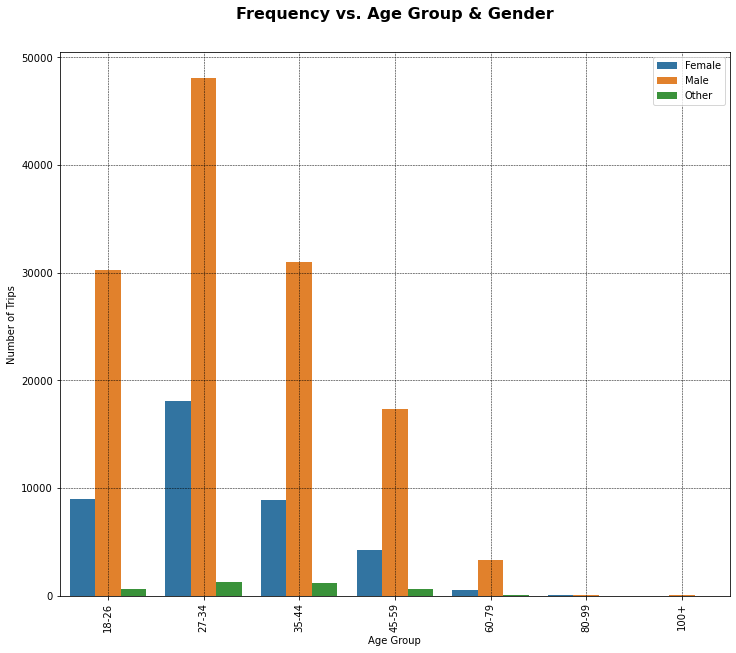

```python
plt.figure(figsize=(12,10))
sns.countplot(x='age_group', hue='member_gender', data=df)
plt.xlabel('Age Group');
plt.xticks(rotation=90);
plt.ylabel('Number of Trips');
plt.legend()
plt.title('Frequency vs. Age Group & Gender', y=1.05, fontsize=16, fontweight='bold', color = 'black');
plt.grid(color = 'black', linestyle = '--', linewidth = 0.5);
```

The plot shows consistent split between age groups & gender split across the different groups as we've seen before

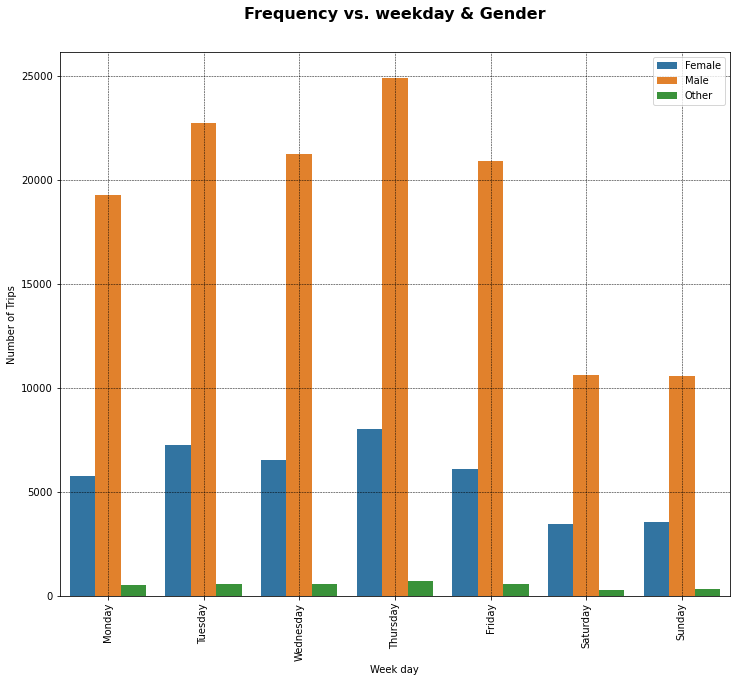

```python
order=['Monday', 'Tuesday', 'Wednesday', 'Thursday', 'Friday', 'Saturday', 'Sunday']
plt.figure(figsize=(12,10))
sns.countplot(x='start_day', hue='member_gender', data=df, order = order)
plt.xlabel('Week day');
plt.xticks(rotation=90);
plt.ylabel('Number of Trips');
plt.legend()
plt.title('Frequency vs. weekday & Gender', y=1.05, fontsize=16, fontweight='bold', color = 'black');
plt.grid(color = 'black', linestyle = '--', linewidth = 0.5);
```

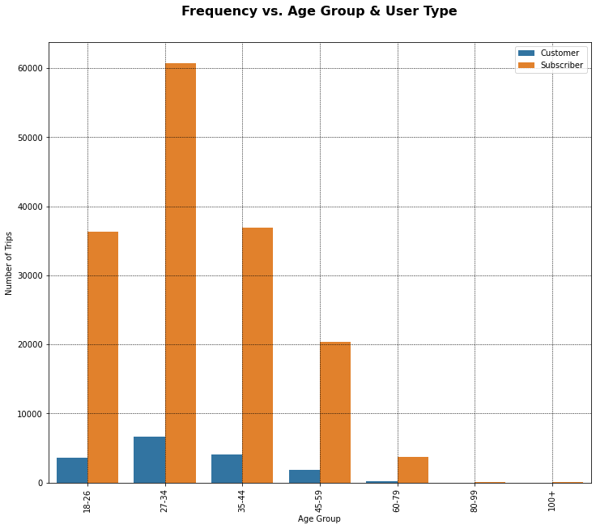

```python
plt.figure(figsize=(12,10))
sns.countplot(x='age_group', hue='user_type', data=df)
plt.xlabel('Age Group');
plt.xticks(rotation=90);
plt.ylabel('Number of Trips');
plt.legend()
plt.title('Frequency vs. Age Group & User Type', y=1.05, fontsize=16, fontweight='bold', color = 'black');
plt.grid(color = 'black', linestyle = '--', linewidth = 0.5);
```

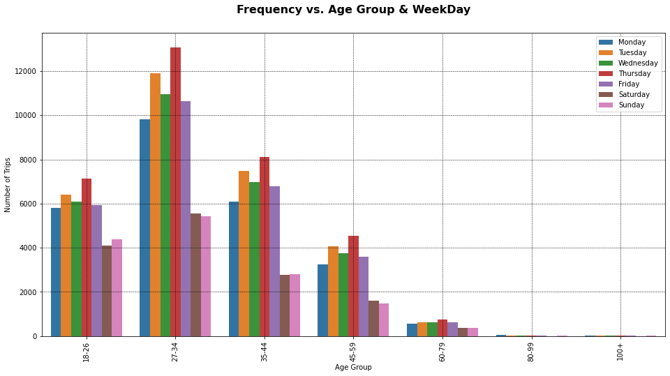

```python
order=['Monday', 'Tuesday', 'Wednesday', 'Thursday', 'Friday', 'Saturday', 'Sunday']
plt.figure(figsize=(16,8))
sns.countplot(x='age_group', hue='start_day', data=df, hue_order=order)
plt.xlabel('Age Group');
plt.xticks(rotation=90);
plt.ylabel('Number of Trips');
plt.legend()
plt.title('Frequency vs. Age Group & WeekDay', y=1.05, fontsize=16, fontweight='bold', color = 'black');
plt.grid(color = 'black', linestyle = '--', linewidth = 0.5);
```

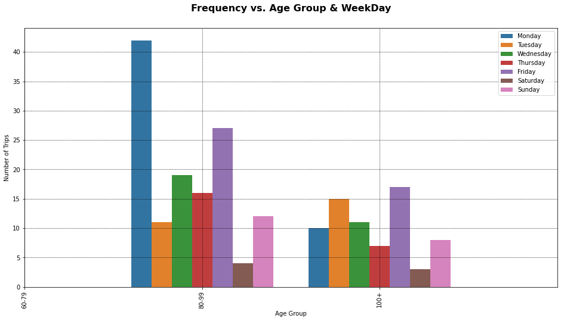

```python
order=['Monday', 'Tuesday', 'Wednesday', 'Thursday', 'Friday', 'Saturday', 'Sunday']
plt.figure(figsize=(16,8))
sns.countplot(data=df.query('age >= 80'), x='age_group', hue='start_day', hue_order=order)
plt.xlabel('Age Group');
plt.xticks(rotation=90);
plt.xlim(4, 7)
plt.ylabel('Number of Trips');
plt.legend()
plt.title('Frequency vs. Age Group & WeekDay', y=1.05, fontsize=16, fontweight='bold', color = 'black');
plt.grid(color = 'black', linestyle = '--', linewidth = 0.5);
```

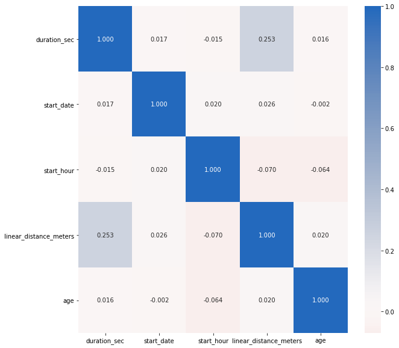

```python
# correlation plot
numeric_vars = ['duration_sec', 'start_date', 'start_hour', 'linear_distance_meters', 'age']
plt.figure(figsize = [10, 10])
sns.heatmap(df[numeric_vars].corr(), annot = True, fmt = '.3f', cmap = 'vlag_r', center = 0);
```

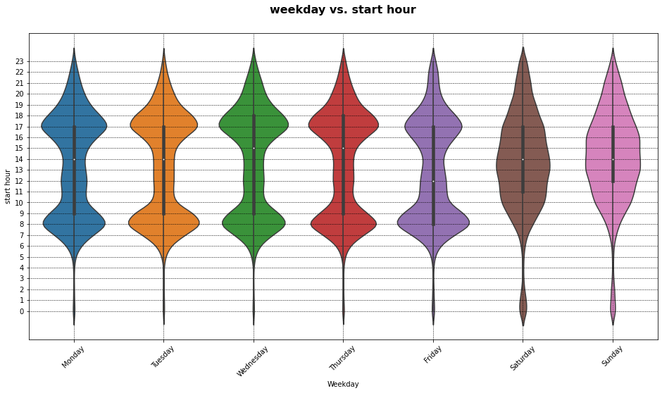

```python
order=['Monday', 'Tuesday', 'Wednesday', 'Thursday', 'Friday', 'Saturday', 'Sunday']
plt.figure(figsize=(16,8))
sns.violinplot(x='start_day', y='start_hour', data=df, order=order)
plt.xlabel('Weekday');
plt.xticks(rotation=45);
plt.ylabel('start hour');
plt.yticks(np.arange(0,24,1))
plt.title('weekday vs. start hour', y=1.05, fontsize=16, fontweight='bold', color = 'black');
plt.grid(color = 'black', linestyle = '--', linewidth = 0.5);
```

It seems that there's more consistency in the peak durations for weekdays with the commuting hypothesis and on weekend it seems that it's more of a normal distribution around the afternoon

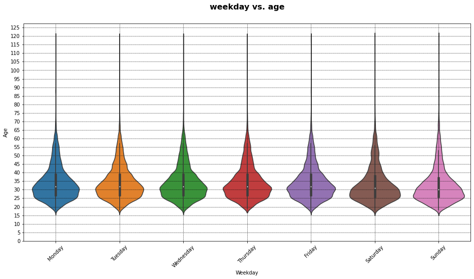

```python
order=['Monday', 'Tuesday', 'Wednesday', 'Thursday', 'Friday', 'Saturday', 'Sunday']
plt.figure(figsize=(16,8))
sns.violinplot(x='start_day', y='age', data=df, order=order)
plt.xlabel('Weekday');
plt.xticks(rotation=45);
plt.ylabel('Age');
plt.yticks(np.arange(0,130,5))
plt.title('weekday vs. age', y=1.05, fontsize=16, fontweight='bold', color = 'black');
plt.grid(color = 'black', linestyle = '--', linewidth = 0.5);
```

it seems that the mean age for weekends is lower than the mean age for weekdays

### Bivariant Exploration Observations

1- Males use Ford Go Bike the least average distance followed by females & then other genders but the mean difference is around 150 meters

2- one time customers have around 12% more distance than subscribers

4- People that use bike share for all trips seem to travel distances 20% of the average user that does't 100% rely on bike share in addition to that exclusive bike share users seem to have higher consentration of trips that have distances around 850 m & 1350 m

5- Mean distance travelled on weekdays is around 8% higher than that of the weekends

6- Peak distance seems to be consitent with the hypothesis of using Ford Go Bike on typical work commuting times with some expectional error margins between 2 & 5am

7- the average distance travelled per day seems to be consistent with both the weekday vs. weekend statement & the Feb 13th & Feb 25th are still showing unexpected values

8- The Average distance travelled per age group seems to disagree with the count when it comes to age group split as the majority of the users seem to fall between 1050m & 1150m with a small error margin below the 50m while more senior users seem to have varying fluctuation in their distance as it is logical to drop with age but it's unexplained for users above the age of 100

11- weekends seem to have higher average durations than weekdays which is against what we have seen in distances which suggests that are usually slower on weekends and implies that more zero distance trips (errands or recreational) happen on weekends.

12- The durations seem to drop in the commuting times in addition to having outliers & a wide margin of error in trips between midnight & dawn. which can somehow be explained by 2 far fetched hypothesis of: 1- People mainly use Ford Go bike to escape traffic in commuting times as durations decrease with the increase of the distance which somehow implies that traffic usually peaks during commuting hours. in addition to the recrational use mentioned before 2- people might forget to properly end their trips when riding at late nights which can explain the huge error & sudden spike in numbers but this needs a totally seperate investigations

14- It seems that there's more consistency in the peak durations for weekdays with the commuting hypothesis and on weekend it seems that it's more of a normal distribution around the afternoon

15- The mean age for weekends is lower than the mean age for weekdays

## MultiVariant Exploration

1- Daily Usage per Usertype & Gender

2- Daily Usage per Age Group & Gender

3- Daily Usage per User Type, Age Group & Gender

4- Daily mean distance per User Type, Age Group & Gender

5- Daily mean duration per User Type, Age Group & Gender

6- Hourly Usage by weekday & Gender

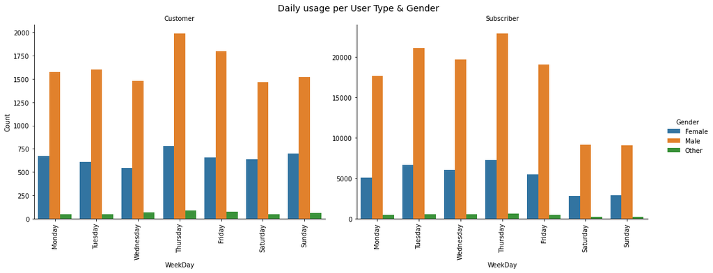

```python
g = sns.catplot(data=df, x='start_day', col="user_type", hue='member_gender', kind='count', aspect=2/1.4, sharey=False, order = order)
g.set_axis_labels('WeekDay', 'Count')
g.set_xticklabels(rotation=90)
g._legend.set_title('Gender')
g.set_titles('{col_name}')
g.fig.suptitle('Daily usage per User Type & Gender', fontsize=14, y=1.02);
```

Seems like there percentage of females is higher in customers than that of subscribers, also the number of trips for customers doesn't seem to vary much between weekdays & weekends

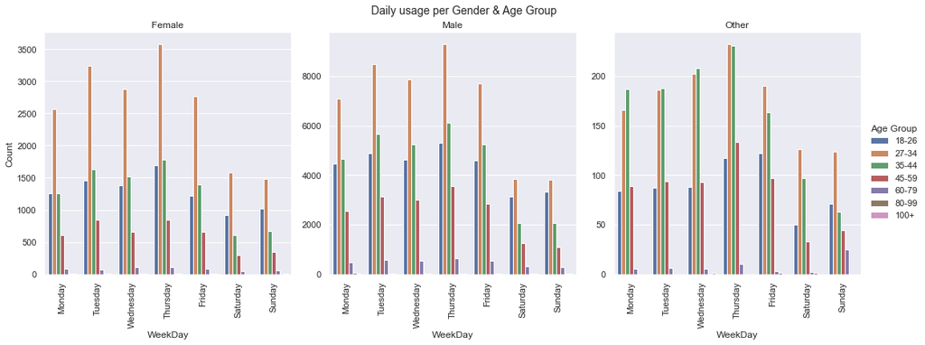

```python
sns.set(rc={'figure.figsize':(16,16)})
g = sns.catplot(data=df, x='start_day', col="member_gender", hue='age_group', kind='count', sharey=False, order = order)
g.set_axis_labels('WeekDay', 'Count')
g.set_xticklabels(rotation=90)
g._legend.set_title('Age Group')
g.set_titles('{col_name}')
g.fig.suptitle('Daily usage per Gender & Age Group', fontsize=14, y=1.02);
```

The highest percentage of nonbinary users lies in the age groups between 27 to 44, also the daily usage doesn't seem to vary much depending on the gender

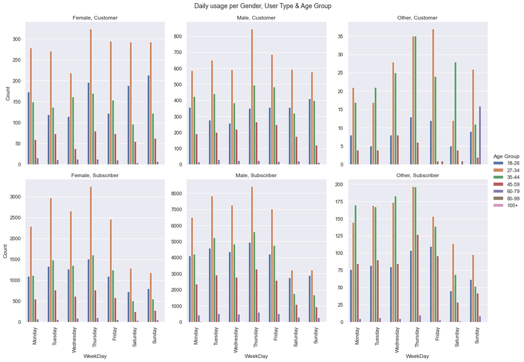

```python
sns.set(rc={'figure.figsize':(21,21)})
g = sns.catplot(data=df, x='start_day', col="member_gender", row='user_type', hue='age_group', kind='count', sharey=False, order = order)
g.set_axis_labels('WeekDay', 'Count', '{row_name}')
g.set_xticklabels(rotation=90)
g._legend.set_title('Age Group')
g.set_titles('{col_name}, {row_name}')
g.fig.suptitle('Daily usage per Gender, User Type & Age Group', fontsize=14, y=1.02);
```

There is consistency across genders & age groups regarding more demand on weekdays than weekends & also the age group split with some exceptions regarding the age group distribution in non-binary users as the age groups vary significantly between one day & another & also vary vs. the typical age group split

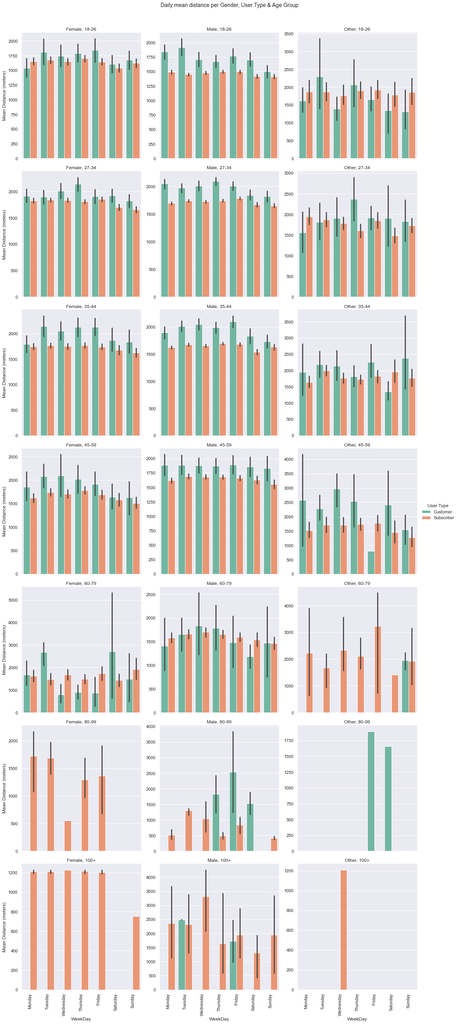

```python
sns.set(rc={'figure.figsize':(16,16)})
g = sns.catplot(data=df, col="member_gender", row='age_group', hue='user_type', palette="Set2",order=order, sharey=False, kind='bar', y='linear_distance_meters', x='start_day')
g.set_axis_labels('WeekDay', 'Mean Distance (meters)', '{row_name}')
g.set_xticklabels(rotation=90)
g._legend.set_title('User Type')
g.set_titles('{col_name}, {row_name}')
g.fig.suptitle('Daily mean distance per Gender, User Type & Age Group', fontsize=14, y=1.02);
```

It looks like that females & other genders have more subscribers than customers specially in the older age groups, also the average distance between genders doesn't seem to vary significantly but their error margin seem to increase with the decrease of the number of samples which is logical. weirdly, looks like females & non-binary users above the age of 100 seem to have a very small error margin and they both seem to be solley subscribers. The most obvious error margins are in the age group between 60-79 & highest amongst females & nonbinary users

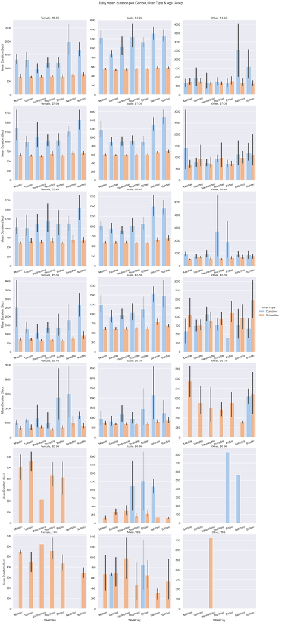

```python
sns.set(rc={'figure.figsize':(16,16)})
plt.subplots_adjust(hspace=1.2)
g = sns.catplot(data=df, col="member_gender", row='age_group', hue='user_type', palette="pastel", order=order, sharey=False, sharex=False, kind='bar', y='duration_sec', x='start_day')
g.set_axis_labels('WeekDay', 'Mean Duration (Sec)', '{row_name}')
g.set_xticklabels(rotation=20)
g._legend.set_title('User Type')
g.set_titles('{col_name}, {row_name}')
g.fig.suptitle('Daily mean duration per Gender, User Type & Age Group', fontsize=14, y=1.02);
```

Seems like customers typically have higher fluctuation in durations vs. subscribers and we can also see similiar trends as the ones seen in distances travelled

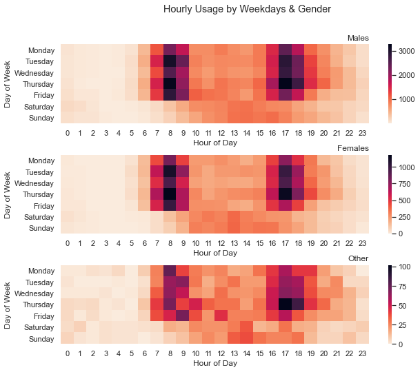

```python
sns.set(rc={'figure.figsize':(10,8)})
plt.subplots_adjust(hspace=0.4)
plt.suptitle('Hourly Usage by Weekdays & Gender')
plt.tight_layout()

plt.subplot(3,1,1)
Male = df.query('member_gender == "Male"')
m_counts = Male.groupby(['start_day', 'start_hour']).size()
m_counts = m_counts.reset_index(name='count')
m_counts = m_counts.pivot(index='start_day', columns='start_hour', values='count')
m_counts = m_counts.reindex(['Monday', 'Tuesday', 'Wednesday', 'Thursday', 'Friday', 'Saturday', 'Sunday'])
sns.heatmap(m_counts, cmap='rocket_r');
plt.title('Males', loc='right');
plt.xlabel('Hour of Day');
plt.ylabel('Day of Week');

plt.subplot(3,1,2)
Female = df.query('member_gender == "Female"')
f_counts = Female.groupby(['start_day', 'start_hour']).size()
f_counts = f_counts.reset_index(name='count')
f_counts = f_counts.pivot(index='start_day', columns='start_hour', values='count')
f_counts = f_counts.reindex(['Monday', 'Tuesday', 'Wednesday', 'Thursday', 'Friday', 'Saturday', 'Sunday'])
sns.heatmap(f_counts, cmap='rocket_r');
plt.title('Females', loc='right');
plt.xlabel('Hour of Day');
plt.ylabel('Day of Week');

plt.subplot(3,1,3)
Other = df.query('member_gender == "Other"')
o_counts = Other.groupby(['start_day', 'start_hour']).size()
o_counts = o_counts.reset_index(name='count')
o_counts = o_counts.pivot(index='start_day', columns='start_hour', values='count')
o_counts = o_counts.reindex(['Monday', 'Tuesday', 'Wednesday', 'Thursday', 'Friday', 'Saturday', 'Sunday'])
sns.heatmap(o_counts, cmap='rocket_r');
plt.title('Other', loc='right');
plt.xlabel('Hour of Day');
plt.ylabel('Day of Week');
```

Hours peak during weekdays at 8 am & 17 pm as suggested before in all genders with the exception of Non-Binary as they peak at 5 & 6 pm Thursday seems to have the highest demand in these hours regardless of the gender Finally looks like the percentage of non-binary users on weekend is higher than that of the other genders

### MultiVariant Exploration Observations

1- The percentage of females is higher in customers than that of subscribers, also the number of trips for customers doesn't seem to vary much between weekdays & weekends which suggests that the majority of errand/recreational trips are done by customers

2- The highest percentage of nonbinary users lies in the age groups between 27 to 44, also the daily usage doesn't seem to depend much on the gender

3- There is consistency across genders & age groups regarding more demand on weekdays than weekends & also the age group split with some exceptions regarding the age group distribution in non-binary users as the age groups vary significantly between one day and another & also vary vs. the typical age group split

4- It looks like that females & other genders have more subscribers than customers specially in the older age groups, also the average distance between genders doesn't seem to vary significantly but their error margin seem to increase with the decrease of the number of samples which is logical. weirdly, looks like females & non-binary users above the age of 100 seem to have a very small error margin and they both seem to be soley subscribers. The most obvious error margins are in the age group between 60-79 & highest amongst females & nonbinary users

5- Customers typically have higher fluctuation in durations vs. subscribers and we can also see similiar trends as the ones seen in distances travelled as they don't fully rely on Ford Go Bike for the routine routes

6- Hours peak during weekdays at 8 am & 17 pm as suggested before in all genders with the exception of Non-Binary as they peak at 5 & 6 pm

7- Thursday seems to have the highest demand in these hours regardless of the gender

8- Finally looks like the percentage of non-binary users on weekend is higher than that of the other genders